# Taisekwa Prediction assingment

Taisekwa Chikazhe

17 September 2021

## Overview

Using devices such as Jawbone Up, Nike FuelBand, and Fitbit it is now possible to collect a large amount of data about personal activity relatively inexpensively. These type of devices are part of the quantified self movement - a group of enthusiasts who take measurements about themselves regularly to improve their health, to find patterns in their behavior, or because they are tech geeks. One thing that people regularly do is quantify how much of a particular activity they do, but they rarely quantify how well they do it.

In this project, we will use data from accelerometers on the belt, forearm, arm, and dumbell of 6 participants. They were asked to perform barbell lifts correctly and incorrectly in 5 different ways.

The data consists of a Training data and a Test data (to be used to validate the selected model).

The goal of your project is to predict the manner in which they did the exercise. This is the “classe” variable in the training set. You may use any of the other variables to predict with.

# Loading required packages

```r
library(rpart)
library(rpart.plot)
library(RColorBrewer)
library(rattle)
library(randomForest)
library(corrplot)
library(gbm)
library(readr)
library(lattice)
library(tidyverse)
library(caret)
library(kernlab)
library(rattle)
library(corrplot)
```

# Load the required data

```r
traincsv <- read_csv("https://d396qusza40orc.cloudfront.net/predmachlearn/pml-training.csv")
```

```
## * `` -> ...1
```

```r
testcsv <- read_csv("https://d396qusza40orc.cloudfront.net/predmachlearn/pml-testing.csv")
```

```
## * `` -> ...1
```

# check for data dimesions

```r
dim(traincsv)
```

```
## [1] 19622   160
```

```r
dim(testcsv)
```

```
## [1]  20 160
```

# Data cleaning

```r
traincsv <- traincsv[,colMeans(is.na(traincsv)) < .9] #removing mostly na columns
traincsv <- traincsv[,-c(1:7)] #removing metadata which is irrelevant to the outcome
dim(traincsv)
```

```
## [1] 19622    53
```

# Partitioning data, into training and testing data set

```r
inTrain <- createDataPartition(y=traincsv$classe, p=0.7, list=F)
train <- traincsv[inTrain,]
valid <- traincsv[-inTrain,]
```

# Ploting correlation plot

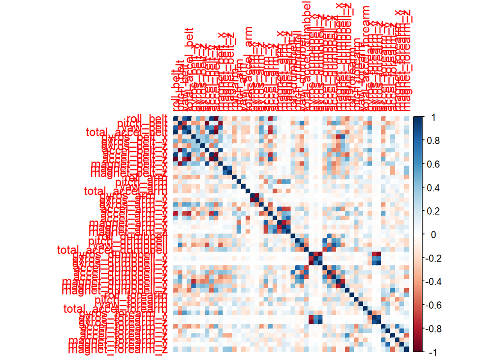

```r
corrPlot <- cor(train[, -length(names(train))])
corrplot(corrPlot, method="color")
```

# Creating and testing models Here we will test a few popular models including: Decision Trees, Random Forest, Gradient Boosted Trees, and SVM.

```r
#Set up control for training to use 3-fold cross validation.
control <- trainControl(method="cv", number=3, verboseIter=F)
```

# Decision tree model

```r
mod_trees <- train(classe~., data=train, method="rpart", trControl = control, tuneLength = 5)
```

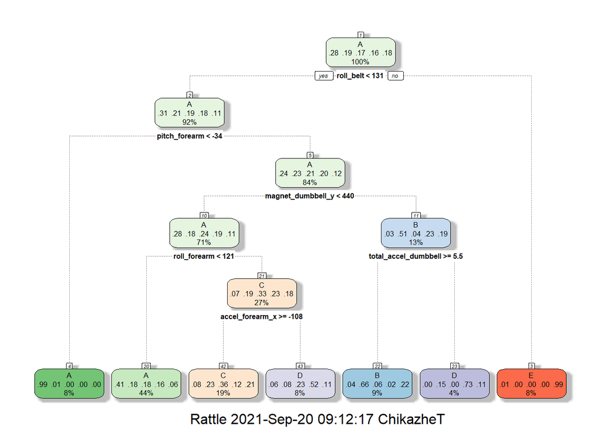

```r
fancyRpartPlot(mod_trees$finalModel)
```

#Prediction

```r
pred_trees <- predict(mod_trees, valid)
cmtrees <- confusionMatrix(pred_trees, factor(valid$classe))
cmtrees
```

```
## Confusion Matrix and Statistics
##
##           Reference
## Prediction    A    B    C    D    E
##          A 1492  467  482  435  157
##          B   29  358   30   14  138
##          C  121  236  422  130  248
##          D   26   78   92  385   59
##          E    6    0    0    0  480
##
## Overall Statistics
##
##                Accuracy : 0.5331
##                  95% CI : (0.5202, 0.5459)
##     No Information Rate : 0.2845
##     P-Value [Acc > NIR] : < 2.2e-16
##
##                   Kappa : 0.3915
##
##  Mcnemar's Test P-Value : < 2.2e-16
##
## Statistics by Class:
##
##                      Class: A Class: B Class: C Class: D Class: E
## Sensitivity            0.8913  0.31431  0.41131  0.39938  0.44362
## Specificity            0.6341  0.95554  0.84873  0.94818  0.99875
## Pos Pred Value         0.4919  0.62917  0.36474  0.60156  0.98765
## Neg Pred Value         0.9362  0.85309  0.87225  0.88961  0.88850
## Prevalence             0.2845  0.19354  0.17434  0.16381  0.18386
## Detection Rate         0.2535  0.06083  0.07171  0.06542  0.08156
## Detection Prevalence   0.5154  0.09669  0.19660  0.10875  0.08258
## Balanced Accuracy      0.7627  0.63493  0.63002  0.67378  0.72119
```

# Decision tree cross validation

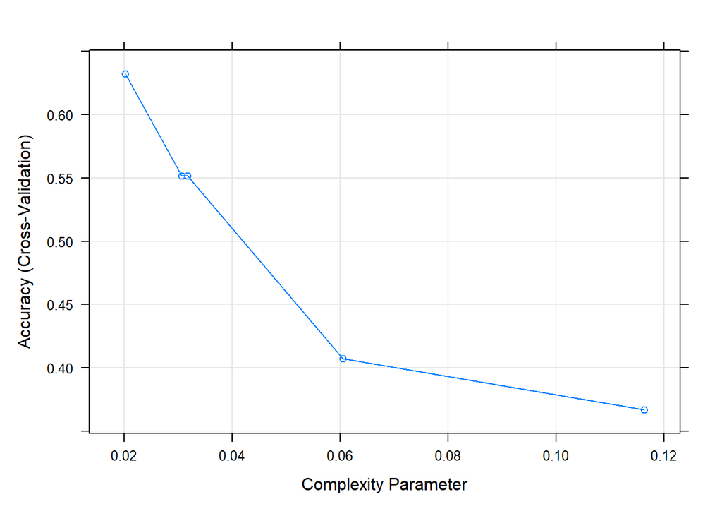

```r
plot(mod_trees)
```

# Random forest model

```r
mod_rf <- train(classe~., data=train, method="rf", trControl = control, tuneLength = 5)
```

# Random forest prediction

```r
pred_rf <- predict(mod_rf, valid)
cmrf <- confusionMatrix(pred_rf, factor(valid$classe))
cmrf
```

```
## Confusion Matrix and Statistics
##
##           Reference
## Prediction    A    B    C    D    E
##          A 1673    4    0    0    0
##          B    1 1133    2    0    0
##          C    0    2 1018    7    3
##          D    0    0    6  955    4
##          E    0    0    0    2 1075
##
## Overall Statistics
##
##                Accuracy : 0.9947
##                  95% CI : (0.9925, 0.9964)
##     No Information Rate : 0.2845
##     P-Value [Acc > NIR] : < 2.2e-16
##
##                   Kappa : 0.9933
##
##  Mcnemar's Test P-Value : NA
##
## Statistics by Class:
##
##                      Class: A Class: B Class: C Class: D Class: E
## Sensitivity            0.9994   0.9947   0.9922   0.9907   0.9935
## Specificity            0.9991   0.9994   0.9975   0.9980   0.9996
## Pos Pred Value         0.9976   0.9974   0.9883   0.9896   0.9981
## Neg Pred Value         0.9998   0.9987   0.9984   0.9982   0.9985
## Prevalence             0.2845   0.1935   0.1743   0.1638   0.1839
## Detection Rate         0.2843   0.1925   0.1730   0.1623   0.1827
## Detection Prevalence   0.2850   0.1930   0.1750   0.1640   0.1830
## Balanced Accuracy      0.9992   0.9971   0.9949   0.9943   0.9966
```

# Random forest cross validation

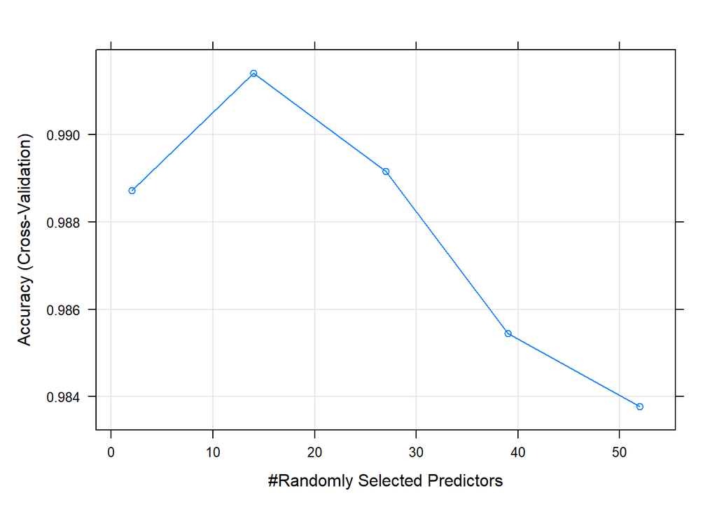

```r
plot(mod_rf)
```

# Gradient boosted trees model

```r
mod_gbm <- train(classe~., data=train, method="gbm", trControl = control, tuneLength = 5, verbose = F)
```

# Gradient boosted trees model prediction

```r
pred_gbm <- predict(mod_gbm, valid)
cmgbm <- confusionMatrix(pred_gbm, factor(valid$classe))
cmgbm
```

```
## Confusion Matrix and Statistics
##
##           Reference
## Prediction    A    B    C    D    E
##          A 1671    8    0    0    0
##          B    3 1124    6    0    3
##          C    0    7 1011   12    3
##          D    0    0    9  949    8
##          E    0    0    0    3 1068
##
## Overall Statistics
##
##                Accuracy : 0.9895
##                  95% CI : (0.9865, 0.9919)
##     No Information Rate : 0.2845
##     P-Value [Acc > NIR] : < 2.2e-16
##
##                   Kappa : 0.9867
##
##  Mcnemar's Test P-Value : NA
##
## Statistics by Class:
##
##                      Class: A Class: B Class: C Class: D Class: E
## Sensitivity            0.9982   0.9868   0.9854   0.9844   0.9871
## Specificity            0.9981   0.9975   0.9955   0.9965   0.9994
## Pos Pred Value         0.9952   0.9894   0.9787   0.9824   0.9972
## Neg Pred Value         0.9993   0.9968   0.9969   0.9970   0.9971
## Prevalence             0.2845   0.1935   0.1743   0.1638   0.1839
## Detection Rate         0.2839   0.1910   0.1718   0.1613   0.1815
## Detection Prevalence   0.2853   0.1930   0.1755   0.1641   0.1820
## Balanced Accuracy      0.9982   0.9922   0.9904   0.9905   0.9932
```

# GBM cross validation

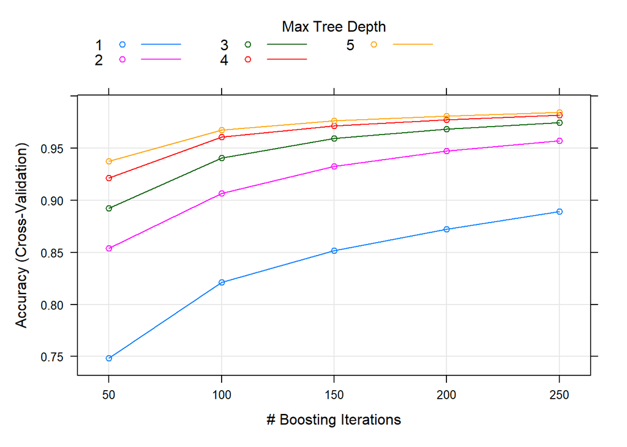

```r
plot(mod_gbm)
```

# Support vector machine model

```r
mod_svm <- train(classe~., data=train, method="svmLinear", trControl = control, tuneLength = 5, verbose = F)
```

# Model prediction

```r
pred_svm <- predict(mod_svm, valid)
cmsvm <- confusionMatrix(pred_svm, factor(valid$classe))
cmsvm
```

```
## Confusion Matrix and Statistics
##
##           Reference
## Prediction    A    B    C    D    E
##          A 1560  159   82   55   67
##          B   24  812  101   43  143
##          C   40   57  792  108   66
##          D   42   26   20  718   62
##          E    8   85   31   40  744
##
## Overall Statistics
##
##                Accuracy : 0.7861
##                  95% CI : (0.7754, 0.7965)
##     No Information Rate : 0.2845
##     P-Value [Acc > NIR] : < 2.2e-16
##
##                   Kappa : 0.7279
##
##  Mcnemar's Test P-Value : < 2.2e-16
##
## Statistics by Class:
##
##                      Class: A Class: B Class: C Class: D Class: E
## Sensitivity            0.9319   0.7129   0.7719   0.7448   0.6876
## Specificity            0.9138   0.9345   0.9442   0.9695   0.9659
## Pos Pred Value         0.8112   0.7231   0.7451   0.8272   0.8194
## Neg Pred Value         0.9712   0.9313   0.9515   0.9510   0.9321
## Prevalence             0.2845   0.1935   0.1743   0.1638   0.1839
## Detection Rate         0.2651   0.1380   0.1346   0.1220   0.1264
## Detection Prevalence   0.3268   0.1908   0.1806   0.1475   0.1543
## Balanced Accuracy      0.9228   0.8237   0.8581   0.8572   0.8267
```

# Results (Accuracy & Out of Sample Error)

[output not shown]